# Transaction analyzes

#### Identifiers

The value `"new"` can be given to the argument `"identifiers"` to assign new identifiers to the patterns regarding the order in which they are plotted.

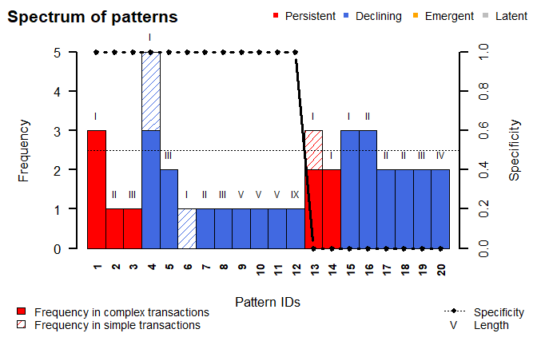

|  | ID | pattern | year | length | support | frequency | f.complex | f.simple | weight | specificity | status |
| --- | --- | --- | --- | --- | --- | --- | --- | --- | --- | --- | --- |
| 5 | 1 | 25 | 2016 | 1 | 0.2142857 | 3 | 3 | 0 | 2 | 1 | Persistent |
| 12 | 2 | 3157, 3350 | 2018 | 2 | 0.0714286 | 1 | 1 | 0 | 1 | 1 | Persistent |
| 15 | 3 | 25 , 27 , 252 | 2018 | 3 | 0.0714286 | 1 | 1 | 0 | 1 | 1 | Persistent |
| 1 | 4 | 3146 | 2014 | 1 | 0.3571429 | 5 | 3 | 2 | 4 | 1 | Declining |
| 6 | 5 | 25 , 192, 328 | 2016 | 3 | 0.1428571 | 2 | 2 | 0 | 1 | 1 | Declining |
| 20 | 6 | 148 | 2011 | 1 | 0.0714286 | 1 | 0 | 1 | 1 | 1 | Declining |
| 13 | 7 | 57, 77 | 2013 | 2 | 0.0714286 | 1 | 1 | 0 | 1 | 1 | Declining |
| 14 | 8 | 49 , 163 , 1603 | 2016 | 3 | 0.0714286 | 1 | 1 | 0 | 1 | 1 | Declining |
| 16 | 9 | 71 , 402 , 931 , 3146, 3180 | 2014 | 5 | 0.0714286 | 1 | 1 | 0 | 1 | 1 | Declining |
| 17 | 10 | 497 , 931 , 3157, 3180, 3345 | 2015 | 5 | 0.0714286 | 1 | 1 | 0 | 1 | 1 | Declining |
| 19 | 11 | 497 , 931 , 3146, 3180, 3345 | 2015 | 5 | 0.0714286 | 1 | 1 | 0 | 1 | 1 | Declining |
| 18 | 12 | 19 , 87 , 252 , 402 , 497 , 929 , 930 , 3146, 3156 | 2016 | 9 | 0.0714286 | 1 | 1 | 0 | 1 | 1 | Declining |
| 4 | 13 | 252 | 2016 | 1 | 0.2142857 | 3 | 2 | 1 | 3 | 0 | Persistent |
| 11 | 14 | 3157 | 2015 | 1 | 0.1428571 | 2 | 2 | 0 | 2 | 0 | Persistent |
| 3 | 15 | 497 | 2015 | 1 | 0.2142857 | 3 | 3 | 0 | 3 | 0 | Declining |
| 2 | 16 | 931 , 3180 | 2014 | 2 | 0.2142857 | 3 | 3 | 0 | 3 | 0 | Declining |
| 8 | 17 | 402 , 3146 | 2014 | 2 | 0.1428571 | 2 | 2 | 0 | 2 | 0 | Declining |
| 10 | 18 | 497 , 3146 | 2015 | 2 | 0.1428571 | 2 | 2 | 0 | 2 | 0 | Declining |
| 9 | 19 | 931 , 3146, 3180 | 2014 | 3 | 0.1428571 | 2 | 2 | 0 | 2 | 0 | Declining |
| 7 | 20 | 497 , 931 , 3180, 3345 | 2015 | 4 | 0.1428571 | 2 | 2 | 0 | 2 | 0 | Declining |

```r
spectrum_chart(TA_instance,
               TA_instance["patterns"],
               identifiers = "new")
```

#### Sorting

The argument `sort` specifies whether to sort the patterns on the chart or to plot them in the given order.

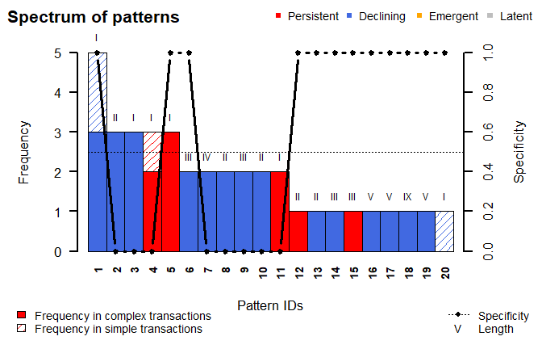

| ID | pattern | year | length | support | frequency | f.complex | f.simple | weight | specificity | status |
| --- | --- | --- | --- | --- | --- | --- | --- | --- | --- | --- |
| 1 | 3146 | 2014 | 1 | 0.3571429 | 5 | 3 | 2 | 4 | 1 | Declining |
| 2 | 931 , 3180 | 2014 | 2 | 0.2142857 | 3 | 3 | 0 | 3 | 0 | Declining |
| 3 | 497 | 2015 | 1 | 0.2142857 | 3 | 3 | 0 | 3 | 0 | Declining |
| 4 | 252 | 2016 | 1 | 0.2142857 | 3 | 2 | 1 | 3 | 0 | Persistent |
| 5 | 25 | 2016 | 1 | 0.2142857 | 3 | 3 | 0 | 2 | 1 | Persistent |
| 6 | 25 , 192, 328 | 2016 | 3 | 0.1428571 | 2 | 2 | 0 | 1 | 1 | Declining |
| 7 | 497 , 931 , 3180, 3345 | 2015 | 4 | 0.1428571 | 2 | 2 | 0 | 2 | 0 | Declining |
| 8 | 402 , 3146 | 2014 | 2 | 0.1428571 | 2 | 2 | 0 | 2 | 0 | Declining |
| 9 | 931 , 3146, 3180 | 2014 | 3 | 0.1428571 | 2 | 2 | 0 | 2 | 0 | Declining |
| 10 | 497 , 3146 | 2015 | 2 | 0.1428571 | 2 | 2 | 0 | 2 | 0 | Declining |
| 11 | 3157 | 2015 | 1 | 0.1428571 | 2 | 2 | 0 | 2 | 0 | Persistent |
| 12 | 3157, 3350 | 2018 | 2 | 0.0714286 | 1 | 1 | 0 | 1 | 1 | Persistent |
| 13 | 57, 77 | 2013 | 2 | 0.0714286 | 1 | 1 | 0 | 1 | 1 | Declining |
| 14 | 49 , 163 , 1603 | 2016 | 3 | 0.0714286 | 1 | 1 | 0 | 1 | 1 | Declining |
| 15 | 25 , 27 , 252 | 2018 | 3 | 0.0714286 | 1 | 1 | 0 | 1 | 1 | Persistent |
| 16 | 71 , 402 , 931 , 3146, 3180 | 2014 | 5 | 0.0714286 | 1 | 1 | 0 | 1 | 1 | Declining |
| 17 | 497 , 931 , 3157, 3180, 3345 | 2015 | 5 | 0.0714286 | 1 | 1 | 0 | 1 | 1 | Declining |
| 18 | 19 , 87 , 252 , 402 , 497 , 929 , 930 , 3146, 3156 | 2016 | 9 | 0.0714286 | 1 | 1 | 0 | 1 | 1 | Declining |
| 19 | 497 , 931 , 3146, 3180, 3345 | 2015 | 5 | 0.0714286 | 1 | 1 | 0 | 1 | 1 | Declining |
| 20 | 148 | 2011 | 1 | 0.0714286 | 1 | 0 | 1 | 1 | 1 | Declining |

```r
spectrum_chart(TA_instance,
               TA_instance["patterns"],
               sort = FALSE)
```

## 4.5. Spectrosome charts

### 4.5.1. Method and arguments

Spectrosome charts are graphs in which vertices are nodes or patterns and edges are the items they have in common. The method to use to plot such graphs is `spectrosome_chart`. The two first argument are an object of class `TransactionAnalyzer` and a data frame of nodes or patterns. The latter can be any subset of the attributes `nodes` and `patterns` of the `TransactionAnalyzer`.

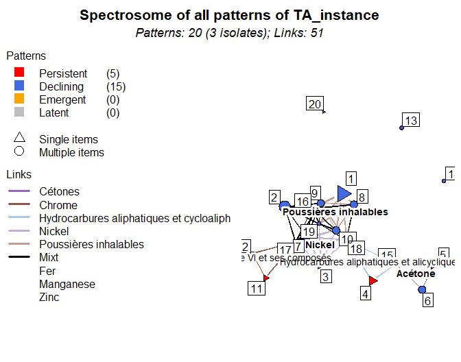

```r
# Spectrosome chart of the patterns of 'TA_instance'
spectrosome_1 <-
  spectrosome_chart(TA_instance,
                    TA_instance["patterns"],
                    title = "Spectrosome of all patterns of TA_instance")
```

Edges are colored according to the possible categories associated with the items. Links composed by several items associated with several values for the represented category are considered as mixed linked and are colored in black. In the legend, category values below “Mixt” are values that are only represented by mixed links.

Clusters corresponding to nodes or patterns sharing one item (i.e. complete subgraphs) are mentioned by displaying the name or code identifying the item between these nodes or patterns. Text relating to clusters confused because all of their links are mixed links (i.e. clusters whose entities all share more than one item) are not displayed.

The list returned by the method contains three elements.

- `vertices`: data frame corresponding to the given one, having two additional columns.
  - `ID`: identifiers of the entities, corresponding to the labels displayed next to the vertices.
  - `degree`: number of entities linked to each entity (i.e. number of vertices to which it is adjacent).
- `edges`: data frame corresponding to the links between the plotted entities. It has the same structure as the attributes `node_links` and `pattern_links`; isolated entities are grouped at the end of the data frame.
- `coords`: list containing the coordinate matrices of the vertices of the graph. It contains as many matrices as there are different graphs (depending on the value of the argument `nb_graphs`, see section Number of graphs below).

Here is the output of the previous call to `spectrosome_chart`.

```r
# Vertices of the previous graph
spectrosome_1$vertices
```

| ID | pattern | year | length | support | frequency | weight | specificity | status | degree |
| --- | --- | --- | --- | --- | --- | --- | --- | --- | --- |
| 1 | 3146 | 2014 | 1 | 0.3571429 | 5 | 4 | 1 | Declining | 6 |
| 2 | 931 , 3180 | 2014 | 2 | 0.2142857 | 3 | 3 | 0 | Declining | 5 |
| 3 | 497 | 2015 | 1 | 0.2142857 | 3 | 3 | 0 | Declining | 5 |
| 4 | 252 | 2016 | 1 | 0.2142857 | 3 | 3 | 0 | Persistent | 2 |
| 5 | 25 | 2016 | 1 | 0.2142857 | 3 | 2 | 1 | Persistent | 2 |
| 6 | 25 , 192, 328 | 2016 | 3 | 0.1428571 | 2 | 1 | 1 | Declining | 2 |
| 7 | 497 , 931 , 3180, 3345 | 2015 | 4 | 0.1428571 | 2 | 2 | 0 | Declining | 8 |
| 8 | 402 , 3146 | 2014 | 2 | 0.1428571 | 2 | 2 | 0 | Declining | 6 |
| 9 | 931 , 3146, 3180 | 2014 | 3 | 0.1428571 | 2 | 2 | 0 | Declining | 9 |
| 10 | 497 , 3146 | 2015 | 2 | 0.1428571 | 2 | 2 | 0 | Declining | 9 |
| 11 | 3157 | 2015 | 1 | 0.1428571 | 2 | 2 | 0 | Persistent | 2 |
| 12 | 3157, 3350 | 2018 | 2 | 0.0714286 | 1 | 1 | 1 | Persistent | 2 |
| 13 | 57, 77 | 2013 | 2 | 0.0714286 | 1 | 1 | 1 | Declining | 0 |
| 14 | 49 , 163 , 1603 | 2016 | 3 | 0.0714286 | 1 | 1 | 1 | Declining | 0 |
| 15 | 25 , 27 , 252 | 2018 | 3 | 0.0714286 | 1 | 1 | 1 | Persistent | 4 |
| 16 | 71 , 402 , 931 , 3146, 3180 | 2014 | 5 | 0.0714286 | 1 | 1 | 1 | Declining | 9 |
| 17 | 497 , 931 , 3157, 3180, 3345 | 2015 | 5 | 0.0714286 | 1 | 1 | 1 | Declining | 10 |
| 18 | 19 , 87 , 252 , 402 , 497 , 929 , 930 , 3146, 3156 | 2016 | 9 | 0.0714286 | 1 | 1 | 1 | Declining | 11 |
| 19 | 497 , 931 , 3146, 3180, 3345 | 2015 | 5 | 0.0714286 | 1 | 1 | 1 | Declining | 10 |
| 20 | 148 | 2011 | 1 | 0.0714286 | 1 | 1 | 1 | Declining | 0 |

```r
# Edges of the previous graph
 spectrosome_1$edges
```

| ID | endpoint.1 | endpoint.2 | items | weight | year |
| --- | --- | --- | --- | --- | --- |
| 1 | 1 | 8 | 3146 | 1 | 2014 |
| 2 | 1 | 9 | 3146 | 1 | 2014 |
| 3 | 1 | 10 | 3146 | 1 | 2015 |
| 4 | 1 | 16 | 3146 | 1 | 2014 |
| 5 | 1 | 18 | 3146 | 1 | 2016 |
| 6 | 1 | 19 | 3146 | 1 | 2015 |
| 7 | 2 | 7 | 931/3180 | 2 | 2015 |
| 8 | 2 | 9 | 931/3180 | 2 | 2014 |
| 9 | 2 | 16 | 931/3180 | 2 | 2014 |
| 10 | 2 | 17 | 931/3180 | 2 | 2015 |
| 11 | 2 | 19 | 931/3180 | 2 | 2015 |
| 12 | 3 | 7 | 497 | 1 | 2015 |
| 13 | 3 | 10 | 497 | 1 | 2015 |
| 14 | 3 | 17 | 497 | 1 | 2015 |
| 15 | 3 | 18 | 497 | 1 | 2016 |
| 16 | 3 | 19 | 497 | 1 | 2015 |
| 17 | 4 | 15 | 252 | 1 | 2018 |
| 18 | 4 | 18 | 252 | 1 | 2016 |
| 19 | 5 | 6 | 25 | 1 | 2016 |
| 20 | 5 | 15 | 25 | 1 | 2018 |
| 21 | 6 | 15 | 25 | 1 | 2018 |
| 22 | 7 | 9 | 931/3180 | 2 | 2015 |
| 23 | 7 | 10 | 497 | 1 | 2015 |
| 24 | 7 | 16 | 931/3180 | 2 | 2015 |
| 25 | 7 | 17 | 497/931/3180/3345 | 4 | 2015 |
| 26 | 7 | 18 | 497 | 1 | 2016 |
| 27 | 7 | 19 | 497/931/3180/3345 | 4 | 2015 |
| 28 | 8 | 9 | 3146 | 1 | 2014 |
| 29 | 8 | 10 | 3146 | 1 | 2015 |
| 30 | 8 | 16 | 402/3146 | 2 | 2014 |
| 31 | 8 | 18 | 402/3146 | 2 | 2016 |
| 32 | 8 | 19 | 3146 | 1 | 2015 |
| 33 | 9 | 10 | 3146 | 1 | 2015 |
| 34 | 9 | 16 | 931/3146/3180 | 3 | 2014 |
| 35 | 9 | 17 | 931/3180 | 2 | 2015 |
| 36 | 9 | 18 | 3146 | 1 | 2016 |
| 37 | 9 | 19 | 931/3146/3180 | 3 | 2015 |
| 38 | 10 | 16 | 3146 | 1 | 2015 |
| 39 | 10 | 17 | 497 | 1 | 2015 |
| 40 | 10 | 18 | 497/3146 | 2 | 2016 |
| 41 | 10 | 19 | 497/3146 | 2 | 2015 |
| 42 | 11 | 12 | 3157 | 1 | 2018 |
| 43 | 11 | 17 | 3157 | 1 | 2015 |
| 44 | 12 | 17 | 3157 | 1 | 2018 |
| 45 | 15 | 18 | 252 | 1 | 2018 |
| 46 | 16 | 17 | 931/3180 | 2 | 2015 |
| 47 | 16 | 18 | 402/3146 | 2 | 2016 |
| 48 | 16 | 19 | 931/3146/3180 | 3 | 2015 |
| 49 | 17 | 18 | 497 | 1 | 2016 |
| 50 | 17 | 19 | 497/931/3180/3345 | 4 | 2015 |
| 51 | 18 | 19 | 497/3146 | 2 | 2016 |
| 52 | 13 | 13 |  | 0 | 2014 |
| 53 | 14 | 14 |  | 0 | 2014 |
| 54 | 20 | 20 |  | 0 | 2015 |

```r
# Coordinates of the vertices of the previous graph
spectrosome_1$coord
```

```
## [[1]]
##                x          y
##  [1,]  4.2001430  1.5195997
##  [2,] -0.4167531  0.5034974
##  [3,]  2.4619668 -4.1014596
##  [4,]  6.5658655 -5.4516780
##  [5,] 11.4867007 -4.1143829
##  [6,] 10.5605151 -6.1480328
##  [7,]  1.3233737 -1.9318456
##  [8,]  5.1075319  0.6607550
##  [9,]  2.4714984  0.7624794
## [10,]  3.6875494 -1.4052014
## [11,] -1.9586065 -5.2045556
## [12,] -2.9964811 -3.2537957
## [13,]  8.9220628  6.7882982
## [14,] 12.3150003  2.5580732
## [15,]  8.4306924 -4.0693305
## [16,]  1.7989836  0.3343375
## [17,]  0.4434376 -2.3283927
## [18,]  4.5160485 -2.1909577
## [19,]  2.3337691 -0.8628394
## [20,]  2.6982505  8.0773587
```

Note that no argument allows to specify which category to represent. If several categories exist, one chart is plotted for each one, keeping the same vertex coordinates and changing the colors and the legend of the links.

Note also that randomness is used for vertices placement. Running the same call multiple times will involve different vertices placement.

#### Item names and category values

By default, if the items were associated to names at initialization of the `TransactionAnalyzer`, these names are displayed. If they were not, their identifiers are displayed. The argument `use_names` specifies whether to display the names (if they exist) or the identifiers.

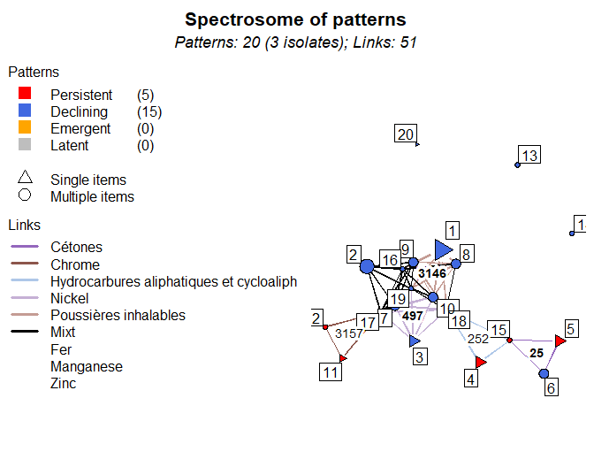

```r
spectrosome_1 <- spectrosome_chart(TA_instance,
                                   TA_instance["patterns"],
                                   coord = spectrosome_1$coords[[1]],
                                   use_names = FALSE)
```

If the item names are displayed, too long names can be easily cut using the argument `n.cutoff` by giving a number of characters. The argument `c.cutoff` does the same for category values in the legend.

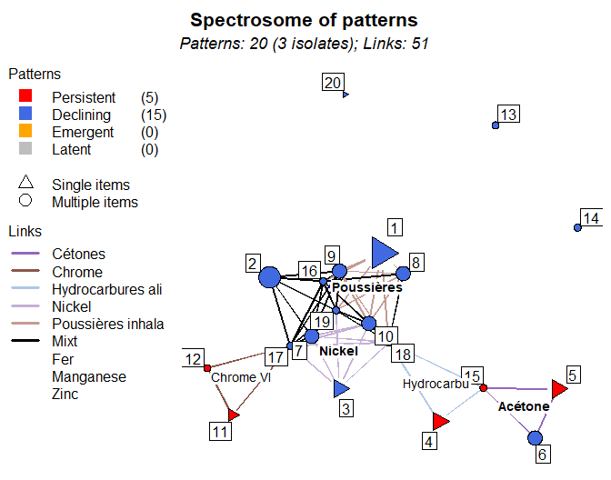

```r
spectrosome_1 <- spectrosome_chart(TA_instance,
                                   TA_instance["patterns"],
                                   coord = spectrosome_1$coords[[1]],
                                   n.cutoff = 10,
                                   c.cutoff = 17)
```

Moreover, the argument `display_mixt` allows to specify whether to display or hide in the legend the category values that are only included in mixed links.

#### Number of graphs

Because vertices placement changes for each call, the argument `nb_graphs` allows to plot multiple graphs at once in order to have more quickly several placement configurations.

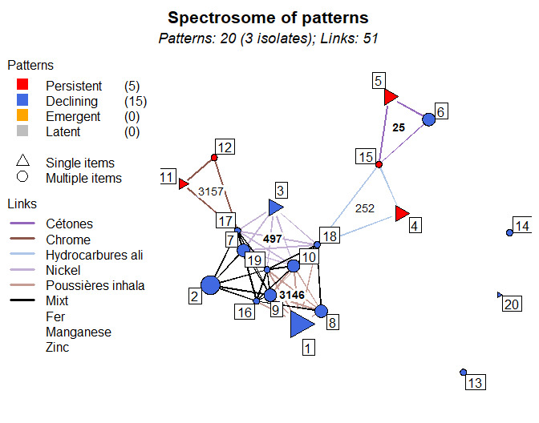

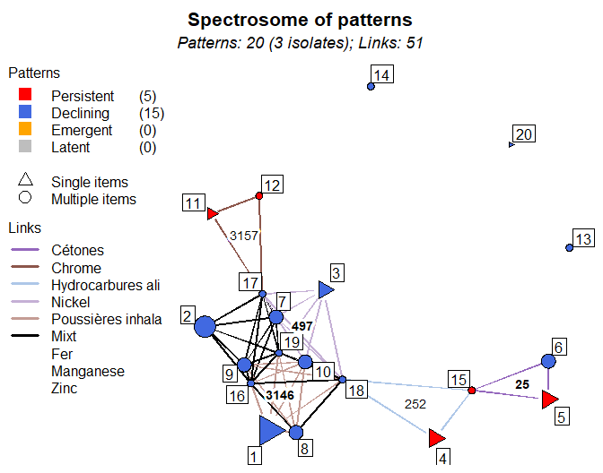

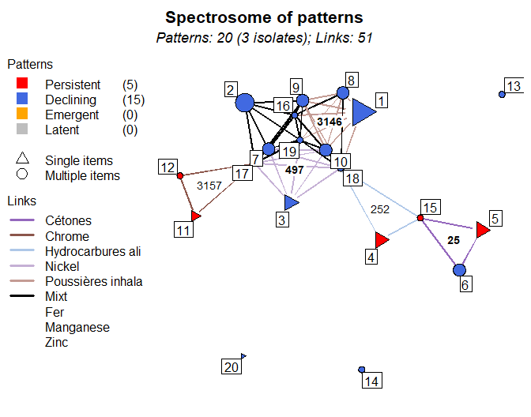

```r
spectrosome_2 <- spectrosome_chart(TA_instance,
                                   TA_instance["patterns"],
                                   use_names = FALSE,
                                   c.cutoff = 17,
                                   nb_graphs = 3)
```

The element `coords` of the returned list contains as many coordinates matrices as there are different graphs. These matrices can be reused afterwards as the `coord` argument.

#### Edges

The argument `min_link_weight` allows to reduce the number of links displayed on a spectrosome according to their weights. The given value specifies the number of items two entities must have in common to plot their link on the chart.

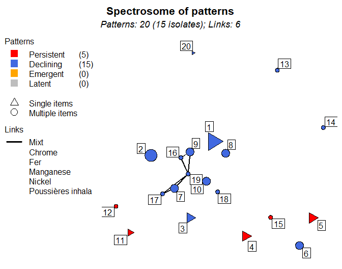

```r
spectrosome_3 <- spectrosome_chart(TA_instance,
                                   TA_instance["patterns"],
                                   coord = spectrosome_1$coords[[1]],
                                   use_names = FALSE,
                                   c.cutoff = 17,
                                   min_link_weight = 3)
```

```r
spectrosome_3$edges
```

|  | ID | endpoint.1 | endpoint.2 | items | weight | year |
| --- | --- | --- | --- | --- | --- | --- |
| 25 | 1 | 7 | 17 | 497/931/3180/3345 | 4 | 2015 |
| 27 | 2 | 7 | 19 | 497/931/3180/3345 | 4 | 2015 |
| 34 | 3 | 9 | 16 | 931/3146/3180 | 3 | 2014 |
| 37 | 4 | 9 | 19 | 931/3146/3180 | 3 | 2015 |
| 48 | 5 | 16 | 19 | 931/3146/3180 | 3 | 2015 |
| 50 | 6 | 17 | 19 | 497/931/3180/3345 | 4 | 2015 |
| 52 | 7 | 13 | 13 |  | 0 | 2014 |
| 53 | 8 | 14 | 14 |  | 0 | 2014 |
| 54 | 9 | 20 | 20 |  | 0 | 2015 |
| A1 | 10 | 1 | 1 |  | 0 | 2014 |
| A2 | 11 | 8 | 8 |  | 0 | 2014 |
| A3 | 12 | 10 | 10 |  | 0 | 2015 |
| A4 | 13 | 18 | 18 |  | 0 | 2016 |
| A5 | 14 | 2 | 2 |  | 0 | 2014 |
| A6 | 15 | 3 | 3 |  | 0 | 2015 |
| A7 | 16 | 4 | 4 |  | 0 | 2016 |
| A8 | 17 | 15 | 15 |  | 0 | 2018 |
| A9 | 18 | 5 | 5 |  | 0 | 2016 |
| A10 | 19 | 6 | 6 |  | 0 | 2016 |
| A11 | 20 | 11 | 11 |  | 0 | 2015 |
| A12 | 21 | 12 | 12 |  | 0 | 2018 |

Since some of the vertices became isolated, these are identified in the returned data frame of links by the rownames starting with “A” for “additional”. These rows corresponds to additional rows not existing in the original data frame of links in attribute.

#### Vertices

Three arguments are relating to the vertices. Their colors can be set using `vertex_col`. Their sizes can be set using `vertex_size` and `size_range`.

The possible values for the argument `vertex_col` are the following.

- `"none"`: the vertices are colored gray.
- `"status"`: if patterns are plotted, the vertices are colored according to their status. If nodes are plotted, consider value `"none"`.
- `"categories"`: the vertices are colored according to the category values associated with the items of the related entities, the same way that links are colored. In this case, the argument `display_mixt` allowing to hide category values that are only included in mixed links also applies to vertices.
- A single character value corresponding to an R predefined color name or a hexadecimal value. The corresponding color is used for all vertices.
- A character vector of R predefined color names or hexadecimal values. The colors are assigned to nodes or patterns to plot. The vector is recycled if it is smaller than the number of entities.

Here are two examples.

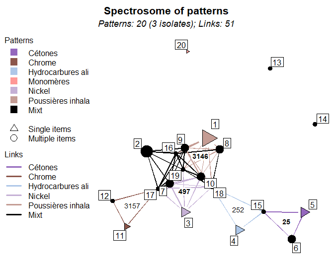

```r
spectrosome_1 <- spectrosome_chart(TA_instance,
                                   TA_instance["patterns"],
                                   coord = spectrosome_1$coords[[1]],
                                   use_names = FALSE,
                                   c.cutoff = 17,
                                   vertex_col = "categories",
                                   display_mixt = FALSE)
```

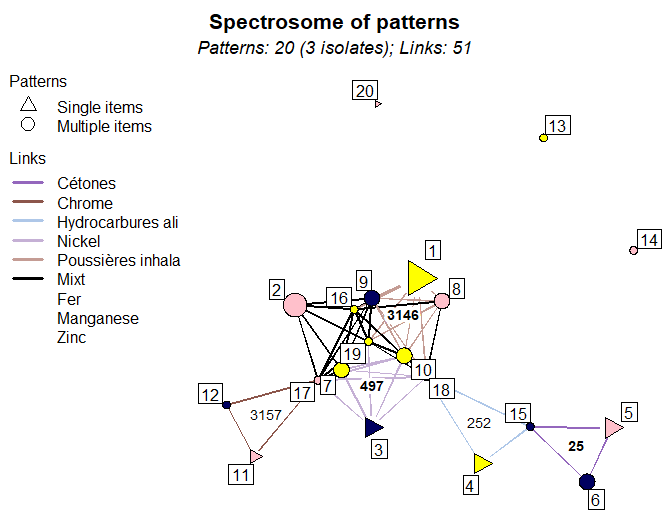

```r
spectrosome_1 <- spectrosome_chart(TA_instance,
                                   TA_instance["patterns"],
                                   coord = spectrosome_1$coords[[1]],
                                   use_names = FALSE,
                                   c.cutoff = 17,
                                   vertex_col = c("yellow", "pink", "#000060"))
```

The possible values for the argument `vertex_size` are the following. The first three are relating to the frequencies of the entities to plot. The last two can have free values.

- `"relative"`: the vertex sizes are defined by a linear interpolation of the frequencies of the entities in the range defined by the argument `size_range`.
- `"grouped"`: the frequency values of the entities are grouped according to five intervals defined by quantiles. The five corresponding size values are taken in a regular sequence bounded by the values of the argument `size_range`.
- `"absolute"`: the vertex sizes correspond to their frequencies.
- A single numeric value: this value is used as the size for all vertices.
- A numeric vector: the values are assigned to the nodes or patterns to plot. The vector is recycled if it is smaller than the number of entities.

The argument `size_range` is a two-length numeric vector given as expansion factors defining the range of vertex size values if the argument `vertex_size` is `"relative"` or `"grouped"`.

Here are two examples.

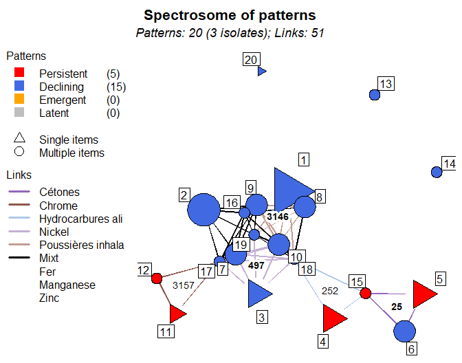

```r
spectrosome_1 = spectrosome_chart(TA_instance,
                                  TA_instance["patterns"],
                                  coord = spectrosome_1$coords[[1]],
                                  use_names = FALSE,
                                  c.cutoff = 17,
                                  vertex_size = "absolute")
```

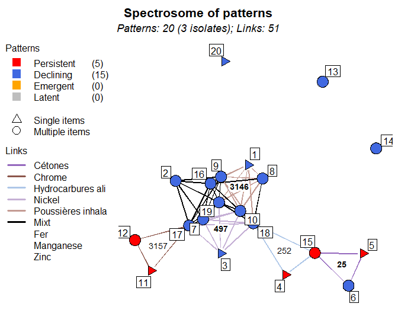

```r
spectrosome_1 = spectrosome_chart(TA_instance,
                                  TA_instance["patterns"],
                                  coord = spectrosome_1$coords[[1]],
                                  use_names = FALSE,
                                  c.cutoff = 17,
                                  vertex_size = 1.2)
```

#### Clusters

Two arguments are relating to naming clusters using labels.

- The argument `clusters` specifies the maximum number of clusters to name on the graph. If the actual number of clusters is greater, the names of the smaller ones are not displayed.
- The argument `highlight` specifies the number of clusters to highlight among those named on the graph. The names of the largest clusters are displayed in bold.

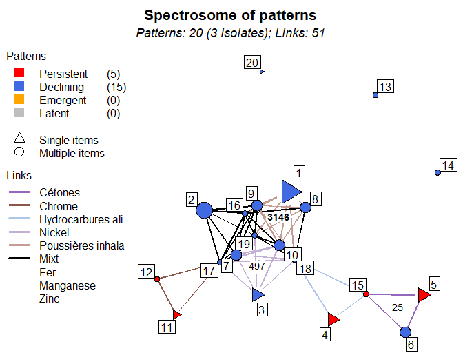

```r
spectrosome_1 = spectrosome_chart(TA_instance,
                                  TA_instance["patterns"],
                                  coord = spectrosome_1$coords[[1]],
                                  use_names = FALSE,
                                  c.cutoff = 17,
                                  clusters = 3,
                                  highlight = 1)
```

The identifiers of the items forming the clusters are sorted in alphanumeric order to define those which are displayed and those highlighted. Therefore, if several clusters are of the same size but the value given to the related argument does not allow all of them to be considered, only the first ones will be, using this order.

For instance, the five clusters relating to the items `3146`, `497`, `25`, `252` and `3157` were displayed in the initial example. But in the last one, since those corresponding to the items `25`, `252`, `3157` have the same size (3 edges); those corresponding to `3146` and `497` are bigger; and the value of the argument `clusters` is `3`, labels for the clusters corresponding to `3146`, `497` and `25` are displayed and clusters corresponding to `252` and `3157` are ignored.

#### Identifiers

The value `"new"` can be given to the argument `"identifiers"` to assign new identifiers to the nodes or patterns plotted. This has effect only if the graph is about a subset of all nodes or a subset of all patterns. In this case, their identifiers are reset starting from 1. Otherwise, they correspond to the original ones.

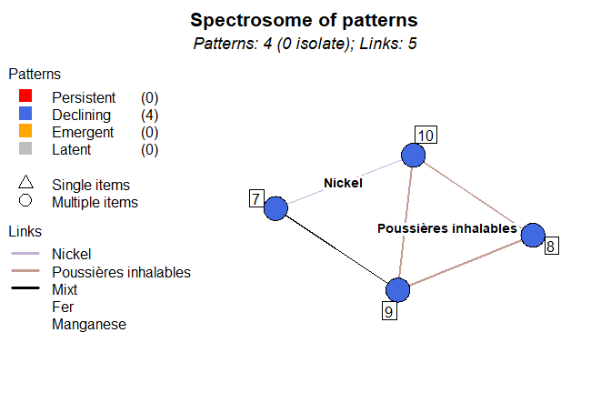

```r
# Plot a spectrosome about the patterns 7 to 10 using original identifiers
spectrosome_4a <- spectrosome_chart(TA_instance,
                                    TA_instance["patterns"][7:10, ],
                                    identifiers = "original")
```

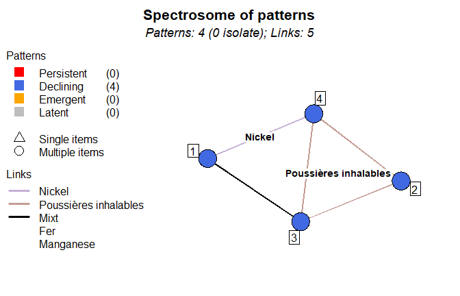

```r
# Plot a spectrosome about the patterns 7 to 10 using new identifiers
spectrosome_4b <- spectrosome_chart(TA_instance,
                                    TA_instance["patterns"][7:10,],
                                    coord = spectrosome_4a$coords[[1]],
                                    identifiers = "new")
```

#### Additional arguments

The graph being plotted using the function `gplot` from the package `sna`, additional arguments can be supplied to this function. Here are some useful ones.

- `displaylabels`: should vertex labels be displayed? Default is `TRUE`.
- `label.pos`: position at which labels should be placed, relative to vertices. `0` results in labels which are placed away from the center of the plotting region; `1`, `2`, `3`, and `4` result in labels being placed below, to the left of, above, and to the right of vertices (respectively); and `label.pos >= 5` results in labels which are plotted with no offset (i.e., at the vertex positions). Default is `0`.
- `boxed.labels`: place vertex labels within boxes? Default is `TRUE`.
- `displayisolates`: should isolates be displayed? Default is `TRUE`.
- `coord`: a two-column matrix specifying the coordinates of the vertices.
- `mode`: vertex placement algorithm. Can be one of `"fruchtermanreingold"`, `"kamadakawai"`, `"circle"`, `"random"` or many others (see the [sna documentation](https://cran.r-project.org/web/packages/sna/sna.pdf)). Default is `"fruchtermanreingold"`.

Here is an example.

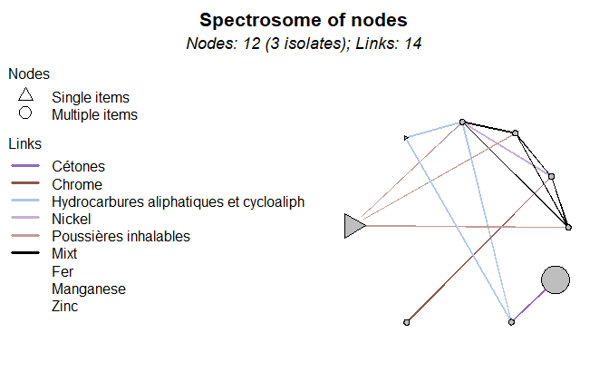

```r
spectrosome_5 <- spectrosome_chart(TA_instance,
                                   TA_instance["nodes"],
                                   clusters = 0,
                                   displaylabels = FALSE,
                                   displayisolates = FALSE,
                                   mode = "circle")
```

### 4.5.2. Additional examples

Since spectrosome charts can be plotted relative to any subset of nodes or patterns, specific graphs can be plotted. Here are some examples.

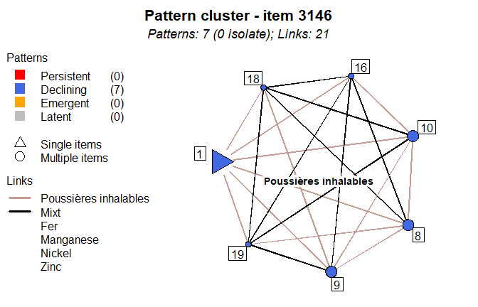

```r
# Extract patterns relating to the item '3146'
patterns_1 <- get_patterns(TA_instance,
                           TA_instance["patterns"],
                           element = "items",
                           value = "3146")

# Plot the cluster of patterns relating to the item '3146'
spectrosome_6 <- spectrosome_chart(TA_instance,
                                   patterns_1,
                                   title = "Pattern cluster - item 3146")
```

```r
spectrosome_6$vertices
```

|  | ID | pattern | year | length | support | frequency | weight | specificity | status | degree |
| --- | --- | --- | --- | --- | --- | --- | --- | --- | --- | --- |
| 1 | 1 | 3146 | 2014 | 1 | 0.3571429 | 5 | 4 | 1 | Declining | 6 |
| 8 | 8 | 402 , 3146 | 2014 | 2 | 0.1428571 | 2 | 2 | 0 | Declining | 6 |
| 9 | 9 | 931 , 3146, 3180 | 2014 | 3 | 0.1428571 | 2 | 2 | 0 | Declining | 6 |
| 10 | 10 | 497 , 3146 | 2015 | 2 | 0.1428571 | 2 | 2 | 0 | Declining | 6 |
| 16 | 16 | 71 , 402 , 931 , 3146, 3180 | 2014 | 5 | 0.0714286 | 1 | 1 | 1 | Declining | 6 |
| 18 | 18 | 19 , 87 , 252 , 402 , 497 , 929 , 930 , 3146, 3156 | 2016 | 9 | 0.0714286 | 1 | 1 | 1 | Declining | 6 |
| 19 | 19 | 497 , 931 , 3146, 3180, 3345 | 2015 | 5 | 0.0714286 | 1 | 1 | 1 | Declining | 6 |

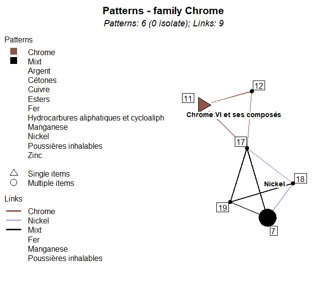

```r
# Extract patterns having items related to the value 'Chrome' of the category
# 'family'
patterns_2 <- get_patterns(TA_instance,
                           TA_instance["patterns"],
                           element = "family",
                           value = "Chrome",
                           condition = "items")

# Plot the spectrosome of the extracted patterns
spectrosome_7 <- spectrosome_chart(TA_instance,
                                   patterns_2,
                                   vertex_col = "categories",
                                   title = "Patterns - family Chrome")
```

```r
spectrosome_7$vertices
```

|  | ID | pattern | year | length | support | frequency | weight | specificity | status | degree |
| --- | --- | --- | --- | --- | --- | --- | --- | --- | --- | --- |
| 7 | 7 | 497 , 931 , 3180, 3345 | 2015 | 4 | 0.1428571 | 2 | 2 | 0 | Declining | 3 |
| 11 | 11 | 3157 | 2015 | 1 | 0.1428571 | 2 | 2 | 0 | Persistent | 2 |
| 12 | 12 | 3157, 3350 | 2018 | 2 | 0.0714286 | 1 | 1 | 1 | Persistent | 2 |
| 17 | 17 | 497 , 931 , 3157, 3180, 3345 | 2015 | 5 | 0.0714286 | 1 | 1 | 1 | Declining | 5 |
| 18 | 18 | 19 , 87 , 252 , 402 , 497 , 929 , 930 , 3146, 3156 | 2016 | 9 | 0.0714286 | 1 | 1 | 1 | Declining | 3 |
| 19 | 19 | 497 , 931 , 3146, 3180, 3345 | 2015 | 5 | 0.0714286 | 1 | 1 | 1 | Declining | 3 |

To finish this section concerning spectrosome graphs, the next two examples use another `TransactionAnalyzer` object created from other data. It is relating to many more transactions and patterns but will not be described in this document; only some spectrosome charts are presented. Note however that this concerns occupational exposure to chemical substances as well, and therefore, a category named “family” is also associated with the items.

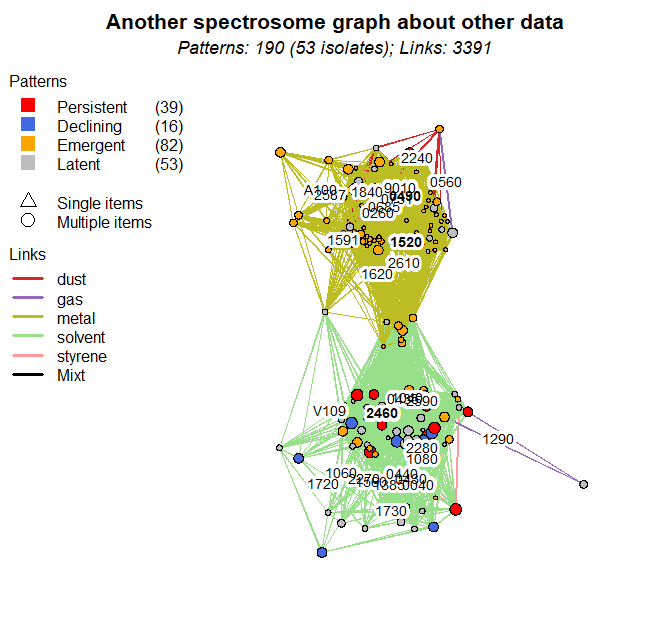

```r
# Spectrosome chart of the patterns of 'another_ta_object'
spectrosome_8 <- spectrosome_chart(
  another_ta_object,
  another_ta_object["patterns"],
  vertex_size = "grouped",
  size_range = c(0.5, 1.5),
  displayisolates = FALSE,
  displaylabels = FALSE,
  title = "Another spectrosome graph about other data"
)
```

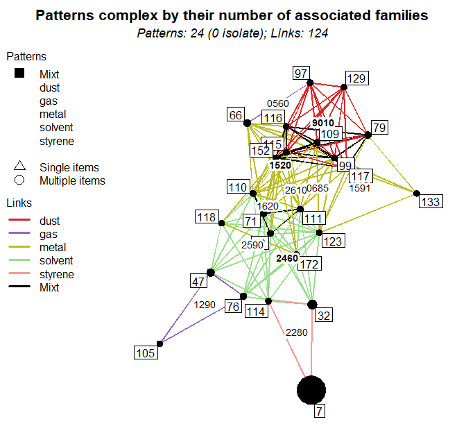

```r
# Focus on the patterns that make the junction between two or more families of
# substances (i.e. two values of one specific category)
patterns_3 <- get_complexes(another_ta_object,
                            another_ta_object["patterns"],
                            category = "family",
                            condition = "vertices",
                            min_nb_values = 2)

# Plot these specific patterns
spectrosome_9 <- spectrosome_chart(
  another_ta_object,
  patterns_3,
  vertex_col = "categories",
  title = "Patterns complex by their number of associated families")
```

Note the use of the value `"vertices"` as the argument `condition` of the method `get_complexes`. This has the same use as `"items"` but is more explicit when focusing on spectrosome graphs instead of data frames of nodes or patterns. In the same way, the value `"edges"` has the same use as `"links"`.

## 4.6. Association rule charts

Association rules can be plotted using the method `rules_chart`. In this kind of chart, only rules of length $2$ are plotted, i.e. having one item as antecedent and another one as consequent. The chart is a graph in which vertices are items and edges are association rules. One characteristic of the rules is represented on the edges by coloring them. As the support, the lift, the frequency and the accuracy from one rule to its reciprocal are equivalent, graphs representing these characteristics are undirected. Conversely, graphs representing the confidence, the specificity or the added value are directed.

The argument `display` defines which characteristic of the rules to represent on the graph: `"support"`, `"confidence"`, `"lift"`, `"frequency"`, `"specificity"`, `"accuracy"` or `"added.value"`. Concerning the confidence, the specificity and the added value, edges may be divided in two parts using two colors to represent the direction of the rules. The part of the edge corresponding to the consequent of the rule is colored according to the value of the rule. The other part is colored according to the value of the reciprocal rule.

In directed graph, the value given to the argument `display` can be preceded by `"highest "` or `"lowest "` (e.g. `"highest confidence"`) to choose between visualizing a rule or its reciprocal instead of visualizing both rules. Only the rule having the highest or lowest value of the desired characteristic will be represented among the two rules existing between two items, unless they have the same value. If `display` refers to highest or lowest values, the argument `direction` allows to keep a gradual opacity on the edges to represent the direction of the displayed rules.

All rules of length $2$ are automatically extracted from the transactions of the given `TransactionAnalyzer` object. Finally, like other charts, the values of one category can be taken into account using the argument `category`.

Here is an example. Further examples using different values of the argument `display` are proposed in the next sections.

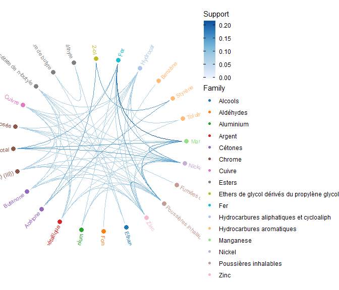

|  | antecedent | consequent | frequency | support | confidence | lift |
| --- | --- | --- | --- | --- | --- | --- |
| 95 | 19 | 3146 | 1 | 0.0714286 | 1.0000000 | 2.800000 |
| 96 | 3146 | 19 | 1 | 0.0714286 | 0.2000000 | 2.800000 |
| 97 | 25 | 252 | 1 | 0.0714286 | 0.3333333 | 1.555556 |
| 98 | 252 | 25 | 1 | 0.0714286 | 0.3333333 | 1.555556 |
| 99 | 3345 | 3180 | 2 | 0.1428571 | 1.0000000 | 4.666667 |
| 100 | 3180 | 3345 | 2 | 0.1428571 | 0.6666667 | 4.666667 |
| 101 | 3345 | 931 | 2 | 0.1428571 | 1.0000000 | 4.666667 |
| 102 | 931 | 3345 | 2 | 0.1428571 | 0.6666667 | 4.666667 |
| 103 | 3345 | 497 | 2 | 0.1428571 | 1.0000000 | 4.666667 |
| 104 | 497 | 3345 | 2 | 0.1428571 | 0.6666667 | 4.666667 |

```r
# Extract and create a graph of all rules of length 2, representing support
rules_3 <- rules_chart(TA_instance,
                       category = "family",
                       display = "support")

# Plot the graph and print the characteristics of some rules
plot(rules_3$graph)
rules_3$rules[95:104, ]
```

The list returned by the method contains two elements.

- `graph`: the graph created, ready to be plotted.
- `rules`: a data frame of the rules represented on the chart and their reciprocals.

#### Rules

Specific rules extracted beforehand can be plotted using the argument `rules`. Otherwise, the argument `parameter` allows to specify minimum support and minimum confidence of association rules to extract.

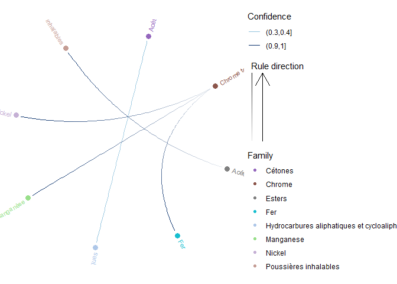

```
## $graph
##
## $rules
##     antecedent consequent frequency    support confidence     lift
## 95          19       3146         1 0.07142857  1.0000000 2.800000
## 96        3146         19         1 0.07142857  0.2000000 2.800000
## 97          25        252         1 0.07142857  0.3333333 1.555556
## 98         252         25         1 0.07142857  0.3333333 1.555556
## 99        3345       3180         2 0.14285714  1.0000000 4.666667
## 100       3180       3345         2 0.14285714  0.6666667 4.666667
## 101       3345        931         2 0.14285714  1.0000000 4.666667
## 102        931       3345         2 0.14285714  0.6666667 4.666667
## 103       3345        497         2 0.14285714  1.0000000 4.666667
## 104        497       3345         2 0.14285714  0.6666667 4.666667
```

```r
# Plot of specific rules, representing highest confidence
rules_chart(TA_instance,
            category = "family",
            display = "highest confidence",
            direction = TRUE,
            rules = rules_3$rules[95:104, ])
```

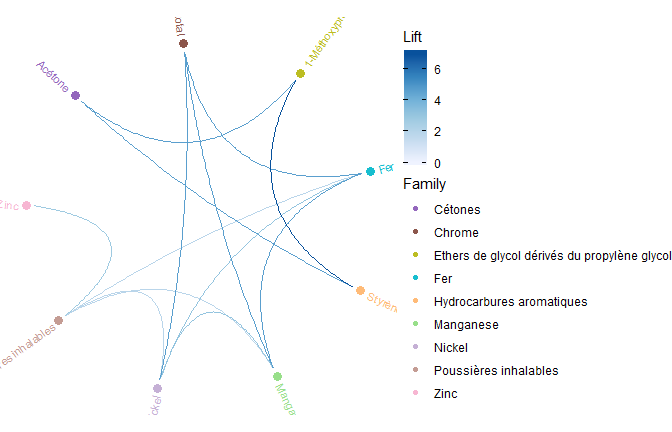

| antecedent | consequent | frequency | support | confidence | lift |
| --- | --- | --- | --- | --- | --- |
| 192 | 328 | 2 | 0.1428571 | 1.0000000 | 7.000000 |
| 328 | 192 | 2 | 0.1428571 | 1.0000000 | 7.000000 |
| 192 | 25 | 2 | 0.1428571 | 1.0000000 | 4.666667 |
| 25 | 192 | 2 | 0.1428571 | 0.6666667 | 4.666667 |
| 328 | 25 | 2 | 0.1428571 | 1.0000000 | 4.666667 |
| 25 | 328 | 2 | 0.1428571 | 0.6666667 | 4.666667 |
| 3345 | 3180 | 2 | 0.1428571 | 1.0000000 | 4.666667 |
| 3180 | 3345 | 2 | 0.1428571 | 0.6666667 | 4.666667 |
| 3345 | 931 | 2 | 0.1428571 | 1.0000000 | 4.666667 |
| 931 | 3345 | 2 | 0.1428571 | 0.6666667 | 4.666667 |
| 3345 | 497 | 2 | 0.1428571 | 1.0000000 | 4.666667 |
| 497 | 3345 | 2 | 0.1428571 | 0.6666667 | 4.666667 |
| 402 | 3146 | 2 | 0.1428571 | 1.0000000 | 2.800000 |
| 3180 | 931 | 3 | 0.2142857 | 1.0000000 | 4.666667 |
| 931 | 3180 | 3 | 0.2142857 | 1.0000000 | 4.666667 |
| 3180 | 497 | 2 | 0.1428571 | 0.6666667 | 3.111111 |
| 497 | 3180 | 2 | 0.1428571 | 0.6666667 | 3.111111 |
| 3180 | 3146 | 2 | 0.1428571 | 0.6666667 | 1.866667 |
| 931 | 497 | 2 | 0.1428571 | 0.6666667 | 3.111111 |
| 497 | 931 | 2 | 0.1428571 | 0.6666667 | 3.111111 |
| 931 | 3146 | 2 | 0.1428571 | 0.6666667 | 1.866667 |
| 497 | 3146 | 2 | 0.1428571 | 0.6666667 | 1.866667 |

```r
# Create a graph about rules of length 2 using parameter
rules_4a <- rules_chart(TA_instance,
                        category = "family",
                        display = "lift",
                        parameter = list(support = 0.1,
                                         confidence = 0.5))

# Plot the graph and print the characteristics of the rules
plot(rules_4a$graph)
rules_4a$rules
```

#### Threshold

The argument `threshold` allows to specify a threshold from which the characteristic referred by the argument `display` must be for a rule to be considered.

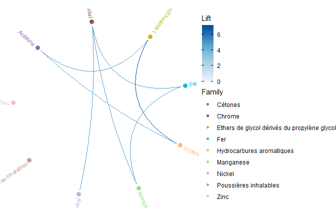

|  | antecedent | consequent | frequency | support | confidence | lift |
| --- | --- | --- | --- | --- | --- | --- |
| 1 | 192 | 328 | 2 | 0.1428571 | 1.0000000 | 7.000000 |
| 2 | 328 | 192 | 2 | 0.1428571 | 1.0000000 | 7.000000 |
| 3 | 192 | 25 | 2 | 0.1428571 | 1.0000000 | 4.666667 |
| 4 | 25 | 192 | 2 | 0.1428571 | 0.6666667 | 4.666667 |
| 5 | 328 | 25 | 2 | 0.1428571 | 1.0000000 | 4.666667 |
| 6 | 25 | 328 | 2 | 0.1428571 | 0.6666667 | 4.666667 |
| 7 | 3345 | 3180 | 2 | 0.1428571 | 1.0000000 | 4.666667 |
| 8 | 3180 | 3345 | 2 | 0.1428571 | 0.6666667 | 4.666667 |
| 9 | 3345 | 931 | 2 | 0.1428571 | 1.0000000 | 4.666667 |
| 10 | 931 | 3345 | 2 | 0.1428571 | 0.6666667 | 4.666667 |
| 11 | 3345 | 497 | 2 | 0.1428571 | 1.0000000 | 4.666667 |
| 12 | 497 | 3345 | 2 | 0.1428571 | 0.6666667 | 4.666667 |
| 14 | 3180 | 931 | 3 | 0.2142857 | 1.0000000 | 4.666667 |
| 15 | 931 | 3180 | 3 | 0.2142857 | 1.0000000 | 4.666667 |

```r
# Plot the previous rules having a lift greater than or equal to 4
rules_4b <- rules_chart(TA_instance,
                        category = "family",
                        rules = rules_4a$rules,
                        display = "lift",
                        threshold = 4)

# Plot the graph and print the characacteristics of the rules
plot(rules_4b$graph)
rules_4b$rules
```

#### Item names and category values

By default, if the items were associated to names at initialization of the `TransactionAnalyzer`, these names are displayed. If they were not, their identifiers are displayed. The argument `use_names` specifies whether to display the names (if they exist) or the identifiers.

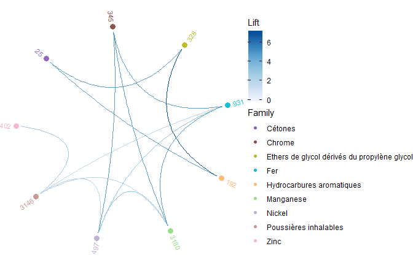

```r
rules_chart(TA_instance,
            category = "family",
            rules = rules_4a$rules,
            display = "lift",
            use_names = FALSE
            )$graph
```

If the names are displayed, too long names can be easily cut using the argument `n.cutoff` by giving a number of characters. The argument `c.cutoff` does the same for category values in the legend.

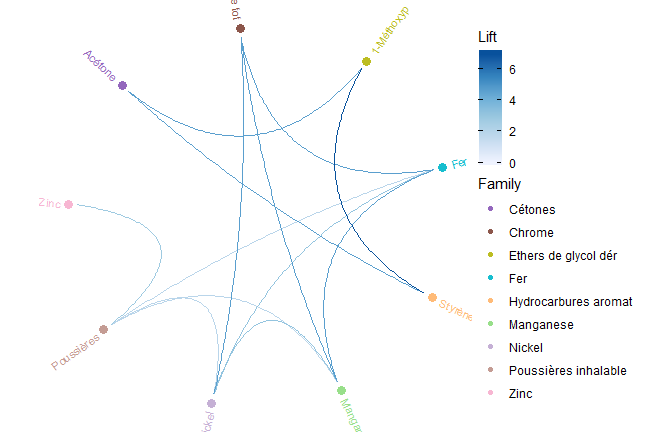

```r
rules_chart(TA_instance,
            category = "family",
            rules = rules_4a$rules,
            display = "lift",
            n.cutoff = 10,
            c.cutoff = 20
            )$graph
```

#### ggplot2

The chart being plotted with the packages `ggraph` and `ggplot2`, it can be modified or completed afterwards using the ggplot2 `last_plot` function or the returned object. We can for example change the plot limits to make truncated labels more visible.

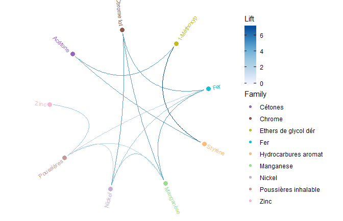

```r
# Loading the package
library(ggplot2)

# Make changes to the last plot
last_plot() + expand_limits(x = c(-1.3, 1.3),
                            y = c(-1.3, 1.3))
```

#### Items and sorting

The argument `items` allows to enlarge or refine the graph by specifying the items to consider.

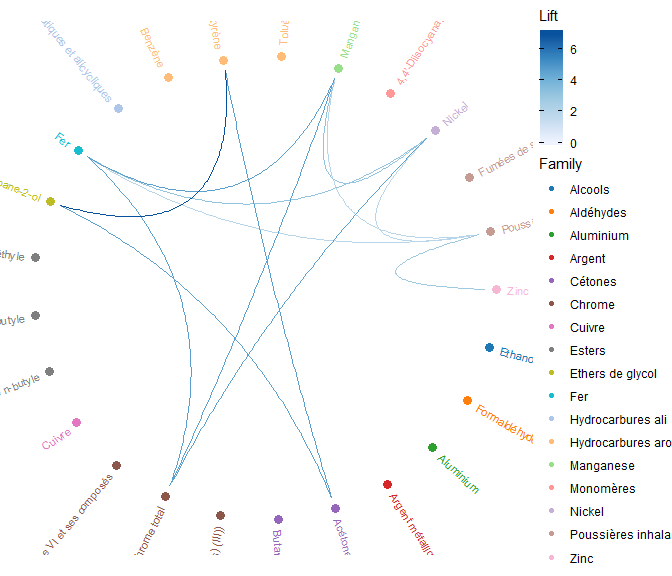

```r
# Plot the previous rules and all items
rules_chart(TA_instance,
            category = "family",
            rules = rules_4a$rules,
            display = "lift",
            c.cutoff = 17,
            items = TA_instance["items"]
            )$graph
```

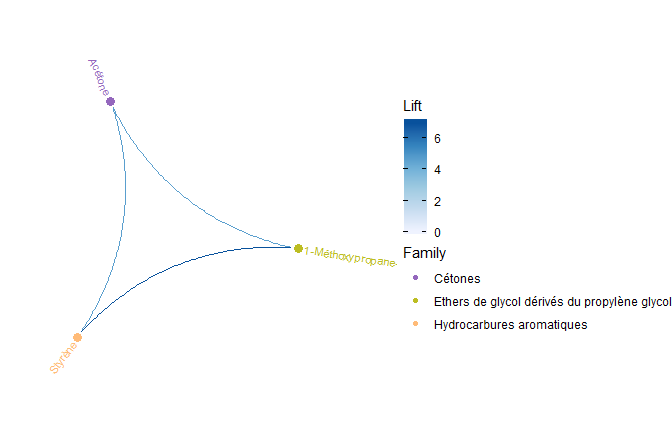

```r
# Plot the part of previous rules relating to 3 specific items
rules_chart(TA_instance,
            category = "family",
            rules = rules_4a$rules,
            display = "lift",
            items = c("25", "192", "328")
            )$graph +
  expand_limits(x = c(-1.1, 1.65),
                y = c(-1.0, 1.2))
```

The argument `sort_by` allows to specify how to sort the items. The possible values are the following.

- `"item"`: items are sorted alphanumerically according to their names or identifiers (according to the value of the argument `use_names`).
- `"category"` (default): items are sorted according to the values of the given category, then alphanumerically.

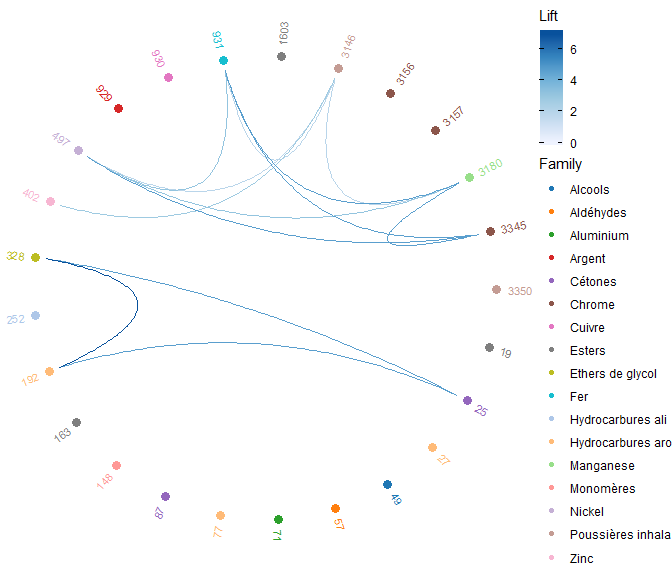

```r
rules_chart(TA_instance,
            category = "family",
            rules = rules_4a$rules,
            display = "lift",
            c.cutoff = 17,
            use_names = FALSE,
            items = TA_instance["items"],
            sort_by = "item"
            )$graph
```

#### Vertices

Three arguments are relating to the vertices. They correspond to their size, their transparency and the space between them and the incident edges: `vertex_size`, `vertex_alpha` and `vertex_margin`.

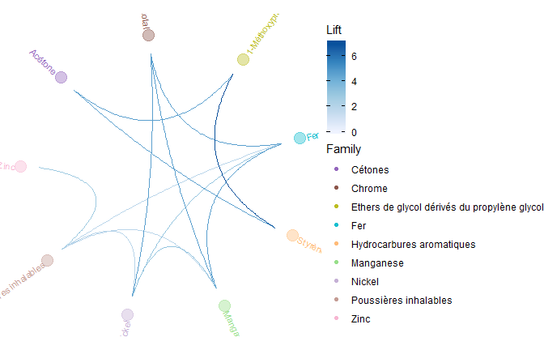

```r
rules_chart(TA_instance,
            category = "family",
            rules = rules_4a$rules,
            display = "lift",
            vertex_size = 5,
            vertex_alpha = 0.4,
            vertex_margin = 0.15
            )$graph
```

#### Labels

Two arguments are relating to the labels next to the vertices. They correspond to their size and the space between them and the related vertices: `label_size` and `label_margin`.

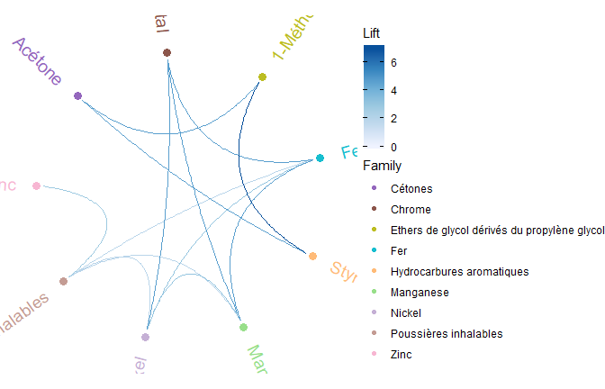

```r
rules_chart(TA_instance,
            category = "family",
            rules = rules_4a$rules,
            display = "lift",
            label_size = 5,
            label_margin = 0.15
            )$graph
```

#### Edges

Two arguments are relating to the edges. They correspond to their looseness and their transparency: `edge_looseness` and `edge_alpha`. Looseness close to $0$ implies straighter lines and value close to $1$ implies more curved lines.

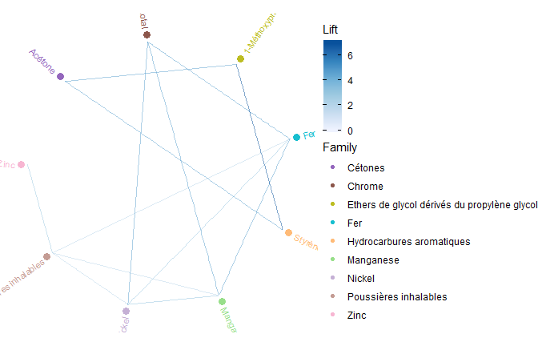

```r
rules_chart(TA_instance,
            category = "family",
            rules = rules_4a$rules,
            display = "lift",
            edge_looseness = 0,
            edge_alpha = 0.5
            )$graph
```

Note that the argument `edge_alpha` can be used only when the argument `display` refers to undirected characteristics.

Note also that the RStudio graphics device may not be able to plot edges with transparency. In such a case, the edges will be actually displayed in the “Plot Zoom” window of the RStudio IDE; while exporting the plot; or by using another graphics device.

#### Palette

Two arguments are relating to the palette used for coloring the edges. The first one allows to specify the palette: `palette`. The available palettes depend on the characteristic referred by the argument `display`.

Here is the list of available palettes if `display` refers to the added value.

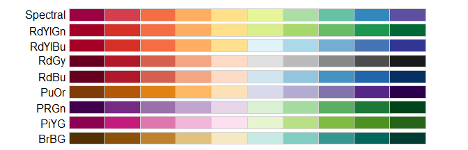

Here is the list of available palettes if `display` refers to a characteristic other than the added value.

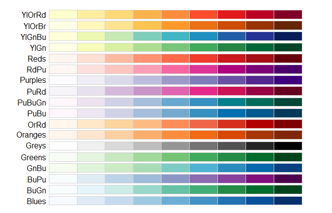

The second palette argument allows to specify the direction: `palette_direction`. It can be $1$: colors are in original order (e.g. from the lightest to the darkest); or $-1$: color order is reversed (e.g. from the darkest to the lightest). It can be used whether to highlight higher values or lower values.

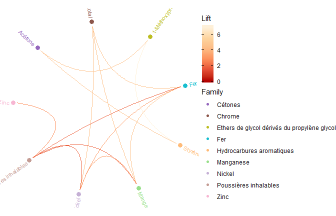

```r
rules_chart(TA_instance,
            category = "family",
            rules = rules_4a$rules,
            display = "lift",
            palette = "OrRd",
            palette_direction = -1
            )$graph
```

# 5. Computations

## 5.1. Computations on patterns

### 5.1.1. Frequency distribution

The method `frequency_by_complexity` counts for each pattern the numbers of complex transactions and simple transactions containing it. The two arguments are a `TransactionAnalyzer` object and a list of pattern itemsets for which to decompose the frequencies between complex and simple transactions (i.e. transactions having more than one and exactly one item).

Here is an example with a comparison to the overall frequencies.

```r
# Decomposed frequencies of all patterns of 'TA_instance'
frequency_by_complexity(TA_instance,
                        patterns = TA_instance["patterns"]$pattern)

# Frequencies of all patterns of 'TA_instance'
TA_instance["patterns"][, c("pattern", "frequency")]
```

```
##       complex simple
##  [1,]       3      2
##  [2,]       3      0
##  [3,]       3      0
##  [4,]       2      1
##  [5,]       3      0
##  [6,]       2      0
##  [7,]       2      0
##  [8,]       2      0
##  [9,]       2      0
## [10,]       2      0
## [11,]       2      0
## [12,]       1      0
## [13,]       1      0
## [14,]       1      0
## [15,]       1      0
## [16,]       1      0
## [17,]       1      0
## [18,]       1      0
## [19,]       1      0
## [20,]       0      1
```

| pattern | frequency |
| --- | --- |
| 3146 | 5 |
| 931 , 3180 | 3 |
| 497 | 3 |
| 252 | 3 |
| 25 | 3 |
| 25 , 192, 328 | 2 |
| 497 , 931 , 3180, 3345 | 2 |
| 402 , 3146 | 2 |
| 931 , 3146, 3180 | 2 |
| 497 , 3146 | 2 |
| 3157 | 2 |
| 3157, 3350 | 1 |
| 57, 77 | 1 |
| 49 , 163 , 1603 | 1 |
| 25 , 27 , 252 | 1 |
| 71 , 402 , 931 , 3146, 3180 | 1 |
| 497 , 931 , 3157, 3180, 3345 | 1 |
| 19 , 87 , 252 , 402 , 497 , 929 , 930 , 3146, 3156 | 1 |
| 497 , 931 , 3146, 3180, 3345 | 1 |
| 148 | 1 |

### 5.1.2. Dynamic status

The method `dynamic_status` allows to get the details of the computations leading to actual pattern status or to get an alternative classification using parameters different from those used at initialization of the `TransactionAnalzyer` object.

The first two arguments are a `TransactionAnalyzer` object and a list of pattern itemsets to classify. The three other arguments are the following.

- `end`: year of end of the periods to consider to characterize the patterns. Default classification uses the last year covered by the transactions of the given `TransactionAnalyzer`.
- `overall_period`: number of years defining (with respect to `end`) the start of the overall time interval over which to consider the given patterns. Default classification uses a value referring to the year of the oldest transaction.
- `recent_period`: number of years defining (with respect to `end`) the start of a shorter time interval to compare with the overall interval. Default classification uses the value of the attribute `status_limit` of the given `TransactionAnalyzer` (whose default value is `2`).

Here is an example.

```r
# Look for the first and last year covered by the transactions of 'TA_instance'
cat("Year of the oldest transaction:     ",
    colnames(TA_instance["nodes_per_year"])[1])

cat("\nYear of the most recent transaction:",
    rev(colnames(TA_instance["nodes_per_year"]))[1])
```

```
## Year of the oldest transaction:      2011
## Year of the most recent transaction: 2018
```

```r
# Classify the patterns
status_1 <- dynamic_status(TA_instance,
                           patterns = TA_instance["patterns"]$pattern,
                           end = 2018,
                           overall_period = 8,
                           recent_period = 2)

status_1$res
status_1$thresholds
```

| RI.overall | is.above.threshold.1 | RI.recent | is.above.threshold.2 | status |
| --- | --- | --- | --- | --- |
| 0.1315789 | TRUE | 0.0 | FALSE | Declining |
| 0.0789474 | TRUE | 0.0 | FALSE | Declining |
| 0.0789474 | TRUE | 0.0 | FALSE | Declining |
| 0.0789474 | TRUE | 0.2 | TRUE | Persistent |
| 0.0789474 | TRUE | 0.2 | TRUE | Persistent |
| 0.0526316 | TRUE | 0.0 | FALSE | Declining |
| 0.0526316 | TRUE | 0.0 | FALSE | Declining |
| 0.0526316 | TRUE | 0.0 | FALSE | Declining |
| 0.0526316 | TRUE | 0.0 | FALSE | Declining |
| 0.0526316 | TRUE | 0.0 | FALSE | Declining |
| 0.0526316 | TRUE | 0.2 | TRUE | Persistent |
| 0.0263158 | TRUE | 0.2 | TRUE | Persistent |
| 0.0263158 | TRUE | 0.0 | FALSE | Declining |
| 0.0263158 | TRUE | 0.0 | FALSE | Declining |
| 0.0263158 | TRUE | 0.2 | TRUE | Persistent |
| 0.0263158 | TRUE | 0.0 | FALSE | Declining |
| 0.0263158 | TRUE | 0.0 | FALSE | Declining |
| 0.0263158 | TRUE | 0.0 | FALSE | Declining |
| 0.0263158 | TRUE | 0.0 | FALSE | Declining |
| 0.0263158 | TRUE | 0.0 | FALSE | Declining |

```
##    threshold.1 threshold.2
## xi 16.00000000         5.0
## RI  0.02631579         0.2
```

The list returned by the method contains the two following elements.

- `res`: a data frame containing the dynamic status of each pattern and the results of intermediate computations.
  - `RI.overall` is the reporting indexes of the patterns for the period defined by the arguments `end` and `overall_period`.
  - `is.above.threshold.1` is a comparison of `RI.overall` and the first RI threshold (present in the second element of the returned list).
  - `RI.recent` is the reporting indexes of the patterns for the period defined by the arguments `end` and `recent_period`.
  - `is.above.threshold.2` is a comparison of `RI.recent` and the second RI threshold (present in the second element of the returned list).
  - `status` is the dynamic status corresponding to the patterns.
- `thresholds`: a matrix containing the $\xi$ (xi) and reporting index (RI) thresholds used to classify the patterns.

Definitions and formulas about dynamic status have been presented in section 1.5.2. Pattern dynamic status. Compared to the classification performed at initialization, the argument `recent_period` corresponds to the limit `l` and the limit at $\infty$ is replaced by a limit corresponding to the argument `overall_period`.

## 5.2. Computations on graphs

### 5.2.1. Network density

The method `network_density` computes the density of a spectrosome graph. It is the ratio between the number of edges of the graph and the number of edges there would be if it was a complete graph (i.e. if all vertices were connected to each other).

The graph is given by its edges as the argument `links`. It must be a data frame using the same structure as the attributes `node_links` and `pattern_links` or the element `edges` returned by the method `spectrosome_chart`.

Here are two examples.

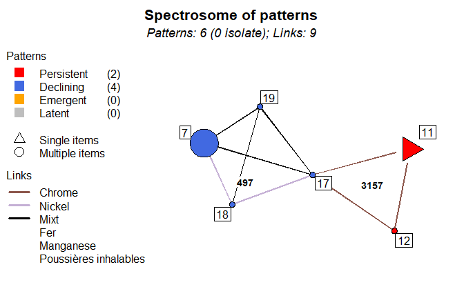

```r
# Spectrosome from a subset of patterns made previously
spectrosome_10 <- spectrosome_chart(TA_instance,
                                    patterns_2,
                                    use_names = FALSE)
```

```r
cat("Network density of the graph:",
    network_density(TA_instance,
                    links = spectrosome_10$edges))
```

```
## Network density of the graph: 0.6
```

```r
# Density of the network of nodes of 'TA_instance'
cat("Network density of the graph formed by all nodes:",
    network_density(TA_instance,
                    links = TA_instance["node_links"]))
```

```
## Network density of the graph formed by all nodes: 0.2121212
```

### 5.2.2. Degree of a vertex

The method `degree` computes the degree of a vertex in a spectrosome graph. It is the number of vertices to which it is adjacent.

The graph is given by its edges as the argument `links`. It must be a data frame using the same structure as the attributes `node_links` and `pattern_links` or the element `edges` returned by the method `spectrosome_chart`. The vertex to focus on is specified by giving its identifier in this graph as the argument `ID`.

Here are some examples.

```r
cat("Degree of the pattern identified 17 in the previous graph:",
    degree(TA_instance,
           ID = 17,
           links = spectrosome_10[["edges"]]))

cat("\nDegree of the first node in the graph of all nodes:",
    degree(TA_instance,
           ID = 1,
           links = TA_instance["node_links"]))
```

```
## Degree of the pattern identified 17 in the previous graph: 5
## Degree of the first node in the graph of all nodes: 6
```

# 6. Save and externalize

## 6.1. Export entities

In addition to `TransactionSet` objects, data frames of nodes, patterns or association rules can be written in CSV format using the method `export`. In these cases, the first two arguments are a `TransactionAnalyzer` object and a data frame. Additional arguments are those of the function `write.csv2` from the package `utils`.

Here are some examples.

```r
# Write in CSV the data relating to the patterns 3 to 7
export(TA_instance,
       TA_instance["patterns"][3:7, ])
```

```
## "";"pattern";"year";"length";"support";"frequency";"weight";"specificity";"status"
## "3";"497";2015;1;0,214285714285714;3;3;0;"Declining"
## "4";"252";2016;1;0,214285714285714;3;3;0;"Persistent"
## "5";"25";2016;1;0,214285714285714;3;2;1;"Persistent"
## "6";"25, 192, 328";2016;3;0,142857142857143;2;1;1;"Declining"
## "7";"497, 931, 3180, 3345";2015;4;0,142857142857143;2;2;0;"Declining"
```

```r
# Write in a CSV file the data frame of nodes
export(TA_instance,
       TA_instance["nodes"],
       file = "nodes.csv")

# Write in a CSV file vertices from a spectrosome graph made previously
export(TA_instance,
       spectrosome_10[["vertices"]],
       file = "vertices.csv")

# Write in a CSV file association rules
export(TA_instance,
       rules_2a,
       file = "rules.csv")
```

Concerning links between nodes or patterns (or edges of a spectrosome graph), writing the related data frames can be done directly using the function `write.csv2` from the package `utils`.

## 6.2. Package arules

`arules` is the package used to mine patterns and association rules. Objects of class `itemsets` or `rules` from this package can be obtained from the mined patterns or assocation rules. Such objects can then be used for complementary analyzes and visualizations.

Patterns can be obtained as object of class `itemsets` by manually initializing an object of class `TransanctionAnalyzer` using the method `init`. Such patterns are returned by initializing the attributes relating to the patterns.

```r
# Creation of a non-initialized TransactionAnalyzer from the transactions
# 'trx_object' created previously
ta_object_3 <- transaction.analyzer(trx_object,
                                    init = FALSE)

# Initalize nodes
init(ta_object_3,
     "nodes",
     verbose = FALSE)

# Initialize patterns and assign the returned object of class itemsets
arules_itemsets <- init(ta_object_3,
                        "patterns",
                        verbose = FALSE)
arules_itemsets
```

```
## set of 20 itemsets
```

Association rules can be obtained as object of class `rules` using the argument `arules` of the method `extract_rules`.

```r
# Extract all rules from the transactions using default mining parameters, as
# rules object
arules_rules <- extract_rules(TA_instance,
                              arules = TRUE)
arules_rules
```

```
## set of 29 rules
```

Such rules can be plotted using methods from the package `arulesViz`. Here is an example.

```
## To reduce overplotting, jitter is added! Use jitter = 0 to prevent jitter.
```

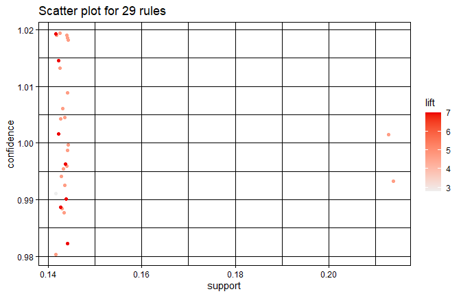

```r
# Loading the package
library(arulesViz)

# Plot a basic chart about rules
plot(arules_rules)
```

See the [arules documentation](https://cran.r-project.org/web/packages/arules/vignettes/arules.pdf) to know how to work with these classes and the [arulesViz documentation](https://cran.csiro.au/web/packages/arulesViz/vignettes/arulesViz.pdf) for more visualizations.

# References

Bosson-Rieutort D, de Gaudemaris R, Bicout DJ (2018). The spectrosome of occupational health problems. *PLoS ONE* 13(1): e0190196. https://doi.org/10.1371/journal.pone.0190196.

Bosson-Rieutort D, Sarazin P, Bicout DJ, Ho V, Lavoué J (2020). Occupational Co-exposures to Multiple Chemical Agents from Workplace Measurements by the US Occupational Safety and Health Administration. *Annals of Work Exposures and Health*, Volume 64, Issue 4, May 2020, Pages 402–415. https://doi.org/10.1093/annweh/wxaa008.

# List of datasets, functions, classes and methods

The package help page: uom.dat

## Datasets

Datasets used as examples:

- oedb_sample
- substances_information
- TS_instance
- TA_instance

## About transaction sets

The class: TransactionSet

Making *TransactionSet* objects:

- transaction.set
- make_transactions
- make_OE_transactions
- [, [[, $ and [<-, [[<-, $<-
- subset
- reorder
- remove_items
- remove_empty_trx

Search in transactions:

- get_all_items
- get_all_years
- get_itemsets
- get_items_from_info
- get_info_from_items

Search for transactions:

- get_trx_from_items
- get_trx_from_info
- get_complex_trx
- get_simple_trx

Computations on transactions:

- complexity_index
- complexity_ratio
- co_occurrence_matrix

Making charts about transactions:

- itemset_chart
- co_occurrence_chart

Saving transactions:

- export

## About transaction analyzes

The class: TransactionAnalyzer

Making *TransactionAnalyzer* objects:

- transaction.analyzer
- init and is_init
- reset
- [ and [<-

Search for transactions, nodes or patterns:

- get_trx_from_category
- get_nodes
- get_patterns
- get_complexes
- get_isolates
- get_non_isolates

Computations on nodes and patterns:

- frequency_by_complexity
- dynamic_status

Search for links between nodes or between patterns:

- get_links

Extracting association rules and switching between mathematical notation and vector notation for sets:

- extract_rules
- vector_notation
- set_notation

Find item names and colors associated with item identifiers and category values associated with itemsets:

- get_item_names
- get_item_colors
- category_values

Making charts:

- itemset_chart
- co_occurrence_chart
- category_tree_chart
- spectrum_chart
- spectrosome_chart
- rules_chart

Computations on spectrosome graphs:

- degree
- network_density

Saving nodes, patterns or association rules:

- export

## About the maximum cumulative ratio approach

Computation of the main indicators:

- hazard_quotient
- hazard_index
- maximum_hazard_quotient
- maximum_cumulative_ratio
- missed_toxicity

Computation of additional indicators:

- reciprocal_of_mcr
- top_hazard_quotient
- classify_mixture

Summarising indicators:

- mcr_summary
- mcr_chart
- thq_pairs
- thq_by_group

Application of the approach according to a classification:

- mcr_approach_by_class
- mcr_summary_by_class
- mcr_chart_by_class
- thq_pairs_by_class
- thq_by_group_by_class

Subsets and reduction of sets:

- reduce_sets
- subset_from_class

## About lists

Computations on lists:

- intersect_on_list
- union_on_list
- table_on_list

Transformation of lists and transformation into lists:

- invert_list
- coerce_list
- coerce_to_list

Search in lists:

- nth_values